# Cost-Effectiveness of SGLT2 Inhibitors vs. Placebo for Heart Failure Prevention in Type 2 Diabetes with Established ASCVD

A Markov model with deterministic and probabilistic sensitivity analysis

Author

Said Adjao

Published

June 27, 2026

## 1 Summary

This analysis evaluates the cost-effectiveness of SGLT2 inhibitors versus placebo for the prevention of heart failure hospitalization in adults with type 2 diabetes and established atherosclerotic cardiovascular disease (ASCVD), using a Markov state-transition model. The treatment effect — a hazard ratio of 0.70 for HF hospitalization — was drawn from an independent meta-analysis of four cardiovascular outcome trials.

At a list price of $6,000/year, the base-case incremental cost-effectiveness ratio (ICER) was **$275,688 per QALY**, exceeding the US willingness-to-pay threshold of $150,000/QALY. The conclusion was robust to uncertainty in the treatment effect but highly sensitive to drug price.

## 2 Background

Heart failure is a frequent, costly complication of type 2 diabetes. SGLT2 inhibitors reduce HF hospitalization, but their value depends on whether the clinical benefit justifies the cost — the central question for payers and health technology assessment. This analysis links a meta-analytic estimate of effectiveness to an economic model to estimate cost per QALY in a defined high-risk population.

## 3 Methods

### 3.1 Model structure

A three-state Markov model (Stable; Post-HF hospitalization; Dead) was run over 20 annual cycles with 3% discounting of costs and QALYs. Patients begin Stable and may transition to Post-HF (a costed event), to Dead (absorbing), or remain. The treatment effect acts solely by reducing the probability of HF hospitalization (baseline rate × HR 0.70); all other parameters are identical between arms.

### 3.2 Parameters

Base-case model inputs (illustrative values).

| Parameter | Value | Source |
| --- | --- | --- |
| HF hospitalization rate (placebo, annual) | 0.040 | Trial placebo arms |
| Hazard ratio (SGLT2i vs placebo) | 0.70 (95% CI 0.62–0.78) | Meta-analysis (4 RCTs) |
| Background mortality (Stable) | 0.020 | Life tables |
| Mortality (Post-HF) | 0.060 | Post-HF literature |
| Drug cost (annual) | $6,000 | Drug pricing (list) |
| HF hospitalization cost | $13,000 | Costing study |
| Utility: Stable | 0.85 | Utility study |
| Utility: Post-HF | 0.70 | Utility study |
| Discount rate | 3% | Convention |
| Time horizon | 20 years | — |

Effectiveness was pooled on the log scale (random-effects); costs and utilities were sourced from standard references. Note that values here are illustrative; a definitive analysis would cite a specific source for each.

## 4 Results

### 4.1 Base case

Base-case costs and QALYs per patient (discounted).

[output not shown]

The base-case ICER was **$275,688 per QALY** — above the US threshold, indicating SGLT2i is not cost-effective at list price under these assumptions.

### 4.2 One-way sensitivity: treatment effect

ICER across the 95% CI of the treatment effect.

| Scenario | ICER |
| --- | --- |
| Optimistic (HR 0.62) | $214,254 |
| Base case (HR 0.70) | $275,688 |
| Pessimistic (HR 0.78) | $381,822 |

Across the full confidence interval of the treatment effect, the ICER remained above $150,000/QALY. The conclusion is therefore robust to uncertainty in effectiveness — the result is driven by other parameters, principally drug cost.

### 4.3 One-way sensitivity: drug price (threshold analysis)

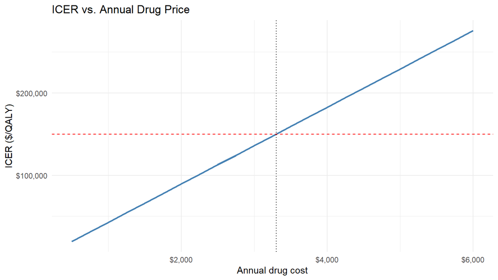

SGLT2i reaches the $150,000/QALY threshold at an annual price of approximately **$3,301**. Because real-world net prices (after rebates) often fall near this range, list-price and net-price analyses can reach opposite conclusions — explaining the divergence between this model and favorable real-world evaluations.

### 4.4 Probabilistic sensitivity analysis

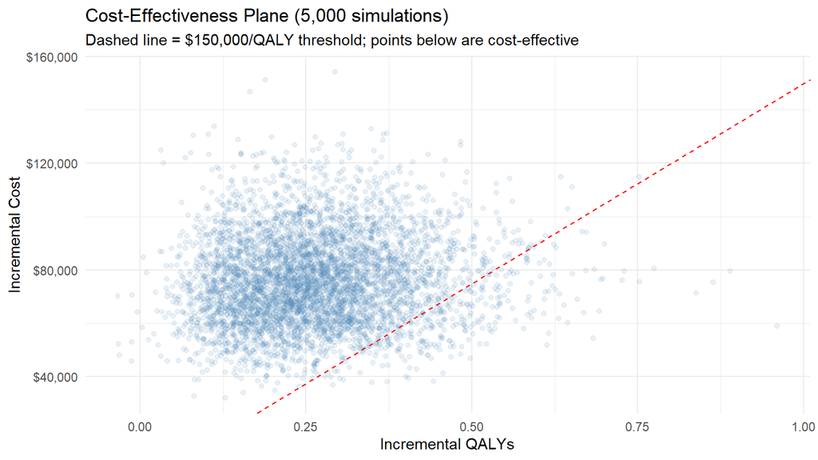

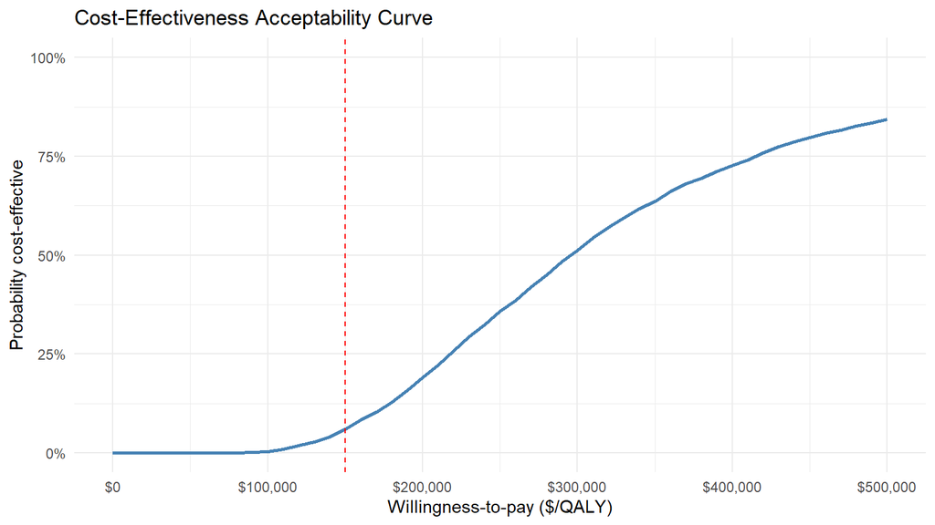

Accounting for all parameter uncertainty simultaneously, SGLT2i had an approximately **6% probability** of being cost-effective at $150,000/QALY at list price. The acceptability curve crosses 50% near the base-case ICER, confirming internal consistency.

## 5 Limitations

This is a simplified three-state model with illustrative inputs; a definitive analysis would source and cite each parameter, model recurrent-event costs explicitly, and extend the survival structure. The base-case verdict is highly sensitive to drug price, and list-price assumptions differ materially from negotiated net prices. Results should be interpreted as a demonstration of method rather than a definitive coverage recommendation.

## 6 Conclusion

SGLT2 inhibitors substantially reduce HF hospitalization (HR 0.70), but at list price the incremental cost per QALY exceeds US willingness-to-pay thresholds in this population. The conclusion is robust to uncertainty in the treatment effect and driven primarily by drug cost; the drug becomes cost-effective at an annual price near $3,301. This illustrates a core HEOR principle: clinical effectiveness does not guarantee cost-effectiveness.